# Effectiveness of HIV treatment combinations - Cox regression with time-varying covariates feat. `data.table`

Brandon Hao

2023-05-25

In this markdown, I’ll demonstrate how to clean the data for a Cox regression with time-varying covarites. The data cleaning is arguably the most difficult part of the the analysis and we’ll make plenty use of `data.table`’s convenient group-wise operations! I’ll also demonstrate the process of fitting the Cox regression model and checking that if the proportional hazards assumption of the model is met.

Without further ado, let’s load in the necessary packages and read in the data.

```r
# Install and load libraries
packages <- c('tidyverse', 'data.table', 'survival', 'DataExplorer', 'survsim', 'broom', 'survminer')

installed_packages <- packages %in% rownames(installed.packages())

if (any(installed_packages == FALSE)) {
  install.packages(packages[!installed_packages])
}

invisible(lapply(packages, require, character.only = TRUE))
# Set file paths
if (!dir.exists('output')) dir.create(file.path('output'))

# Read HIV data
hiv <- file.path(r'{../input/HealthGymV2_CbdrhDatathon_ART4HIV.csv}') %>% fread()
```

Let’s have a look at our dataset.

```r
# Quick look!
glimpse(hiv)
```

```
## Rows: 534,960
## Columns: 15
## $ VL                <dbl> 29.94427, 29.24198, 28.74899, 28.10184, 28.81384, 28…
## $ CD4               <dbl> 793.4583, 467.4189, 465.1248, 692.0069, 641.7571, 44…
## $ `Rel CD4`         <dbl> 30.83451, 30.35598, 30.40532, 30.24882, 29.94471, 30…
## $ Gender            <dbl> 1, 1, 1, 1, 1, 1, 1, 1, 1, 1, 1, 1, 1, 1, 1, 1, 1, 1…
## $ Ethnic            <dbl> 3, 3, 3, 3, 3, 3, 3, 3, 3, 3, 3, 3, 3, 3, 3, 3, 3, 3…
## $ `Base Drug Combo` <dbl> 0, 0, 0, 0, 0, 0, 0, 0, 0, 0, 0, 0, 0, 0, 0, 0, 0, 0…
## $ `Comp. INI`       <dbl> 0, 0, 0, 0, 0, 0, 0, 0, 0, 0, 0, 0, 0, 0, 0, 0, 0, 0…
## $ `Comp. NNRTI`     <dbl> 3, 3, 3, 3, 3, 3, 3, 3, 3, 3, 3, 3, 3, 3, 3, 3, 3, 3…
## $ `Extra PI`        <dbl> 5, 5, 5, 5, 5, 5, 5, 5, 5, 5, 5, 5, 5, 5, 5, 5, 5, 5…
## $ `Extra pk-En`     <dbl> 0, 0, 0, 0, 0, 0, 0, 0, 0, 0, 0, 0, 0, 0, 0, 0, 0, 0…
## $ `VL (M)`          <dbl> 0, 0, 0, 0, 0, 0, 0, 0, 0, 0, 0, 0, 0, 0, 0, 0, 0, 0…
## $ `CD4 (M)`         <dbl> 1, 0, 0, 0, 0, 0, 0, 1, 0, 0, 0, 0, 0, 0, 0, 0, 0, 0…
## $ `Drug (M)`        <dbl> 1, 1, 1, 1, 1, 1, 1, 1, 1, 1, 1, 1, 1, 1, 1, 1, 1, 1…
## $ PatientID         <int> 0, 0, 0, 0, 0, 0, 0, 0, 0, 0, 0, 0, 0, 0, 0, 0, 0, 0…
## $ Timestep          <int> 0, 1, 2, 3, 4, 5, 6, 7, 8, 9, 10, 11, 12, 13, 14, 15…
```

```r
summary(hiv)
```

```
##        VL                CD4              Rel CD4            Gender
##  Min.   :    0.10   Min.   :    7.96   Min.   :  1.871   Min.   :1.000
##  1st Qu.:   10.49   1st Qu.:  272.85   1st Qu.: 17.462   1st Qu.:1.000
##  Median :   38.78   Median :  466.40   Median : 27.734   Median :1.000
##  Mean   : 7041.12   Mean   :  823.08   Mean   : 36.353   Mean   :1.137
##  3rd Qu.:  778.27   3rd Qu.:  859.44   3rd Qu.: 44.152   3rd Qu.:1.000
##  Max.   :97566.41   Max.   :42475.20   Max.   :586.635   Max.   :2.000
##      Ethnic      Base Drug Combo   Comp. INI      Comp. NNRTI       Extra PI
##  Min.   :1.000   Min.   :0.000   Min.   :0.000   Min.   :0.000   Min.   :0.00
##  1st Qu.:3.000   1st Qu.:0.000   1st Qu.:1.000   1st Qu.:2.000   1st Qu.:5.00
##  Median :4.000   Median :1.000   Median :3.000   Median :3.000   Median :5.00
##  Mean   :3.486   Mean   :1.021   Mean   :2.167   Mean   :2.376   Mean   :4.18
##  3rd Qu.:4.000   3rd Qu.:1.000   3rd Qu.:3.000   3rd Qu.:3.000   3rd Qu.:5.00
##  Max.   :4.000   Max.   :5.000   Max.   :3.000   Max.   :3.000   Max.   :5.00
##   Extra pk-En          VL (M)          CD4 (M)          Drug (M)
##  Min.   :0.00000   Min.   :0.0000   Min.   :0.0000   Min.   :0.0000
##  1st Qu.:0.00000   1st Qu.:0.0000   1st Qu.:0.0000   1st Qu.:1.0000
##  Median :0.00000   Median :0.0000   Median :0.0000   Median :1.0000
##  Mean   :0.06688   Mean   :0.1309   Mean   :0.1552   Mean   :0.7768
##  3rd Qu.:0.00000   3rd Qu.:0.0000   3rd Qu.:0.0000   3rd Qu.:1.0000
##  Max.   :1.00000   Max.   :1.0000   Max.   :1.0000   Max.   :1.0000
##    PatientID       Timestep
##  Min.   :   0   Min.   : 0.00
##  1st Qu.:2229   1st Qu.:14.75
##  Median :4458   Median :29.50
##  Mean   :4458   Mean   :29.50
##  3rd Qu.:6686   3rd Qu.:44.25
##  Max.   :8915   Max.   :59.00
```

```r
str(hiv)
```

```
## Classes 'data.table' and 'data.frame':   534960 obs. of  15 variables:
##  $ VL             : num  29.9 29.2 28.7 28.1 28.8 ...
##  $ CD4            : num  793 467 465 692 642 ...
##  $ Rel CD4        : num  30.8 30.4 30.4 30.2 29.9 ...
##  $ Gender         : num  1 1 1 1 1 1 1 1 1 1 ...
##  $ Ethnic         : num  3 3 3 3 3 3 3 3 3 3 ...
##  $ Base Drug Combo: num  0 0 0 0 0 0 0 0 0 0 ...
##  $ Comp. INI      : num  0 0 0 0 0 0 0 0 0 0 ...
##  $ Comp. NNRTI    : num  3 3 3 3 3 3 3 3 3 3 ...
##  $ Extra PI       : num  5 5 5 5 5 5 5 5 5 5 ...
##  $ Extra pk-En    : num  0 0 0 0 0 0 0 0 0 0 ...
##  $ VL (M)         : num  0 0 0 0 0 0 0 0 0 0 ...
##  $ CD4 (M)        : num  1 0 0 0 0 0 0 1 0 0 ...
##  $ Drug (M)       : num  1 1 1 1 1 1 1 1 1 1 ...
##  $ PatientID      : int  0 0 0 0 0 0 0 0 0 0 ...
##  $ Timestep       : int  0 1 2 3 4 5 6 7 8 9 ...
##  - attr(*, ".internal.selfref")=<externalptr>
```

Firstly, the names of the columns suck! Also, there are some variables which should be categorical variables. Let’s clean up the names and transform variables into their proper type.

```r
# Change some names coz they suck
names(hiv) <- c(
  'vl', 'cd4', 'relcd4', 'gender', 'ethnic', 'base_drug_comb', 'ini', 'nnrti', 'pi', 'pk', 'vl_m', 'cd4_m', 'drug_m', 'id', 'time'
  )

# Transform columns into Boolean
boolean_cols <- hiv %>% select(pk:drug_m) %>% names()
hiv[, (boolean_cols) := lapply(.SD, as.logical), .SDcols = boolean_cols]

# Factorise certain columns and give sensible levels
factor_cols <- hiv %>% select(gender:pi) %>% names()
hiv[, (factor_cols) := lapply(.SD, as.factor), .SDcols = factor_cols]

levels(hiv$gender) <- c('male', 'female')
levels(hiv$ethnic) <- c('asian', 'afro', 'caucasian', 'other')
levels(hiv$base_drug_comb) <- c('ftc_tdf','3tc_abc', 'ftc_taf', 'drv_ftc_tdf', 'ftc_rtvb_tdf', 'other')
levels(hiv$ini) <- c('dtg', 'ral', 'evg', 'not_applied')
levels(hiv$nnrti) <- c('nvp', 'efv', 'rpv', 'not_applied')
levels(hiv$pi) <- c('drv', 'rtvb', 'lpv', 'rtv', 'atv', 'not_applied')

# Make sure the format is properly transformed
str(hiv)
```

```
## Classes 'data.table' and 'data.frame':   534960 obs. of  15 variables:
##  $ vl            : num  29.9 29.2 28.7 28.1 28.8 ...
##  $ cd4           : num  793 467 465 692 642 ...
##  $ relcd4        : num  30.8 30.4 30.4 30.2 29.9 ...
##  $ gender        : Factor w/ 2 levels "male","female": 1 1 1 1 1 1 1 1 1 1 ...
##  $ ethnic        : Factor w/ 4 levels "asian","afro",..: 3 3 3 3 3 3 3 3 3 3 ...
##  $ base_drug_comb: Factor w/ 6 levels "ftc_tdf","3tc_abc",..: 1 1 1 1 1 1 1 1 1 1 ...
##  $ ini           : Factor w/ 4 levels "dtg","ral","evg",..: 1 1 1 1 1 1 1 1 1 1 ...
##  $ nnrti         : Factor w/ 4 levels "nvp","efv","rpv",..: 4 4 4 4 4 4 4 4 4 4 ...
##  $ pi            : Factor w/ 6 levels "drv","rtvb","lpv",..: 6 6 6 6 6 6 6 6 6 6 ...
##  $ pk            : logi  FALSE FALSE FALSE FALSE FALSE FALSE ...
##  $ vl_m          : logi  FALSE FALSE FALSE FALSE FALSE FALSE ...
##  $ cd4_m         : logi  TRUE FALSE FALSE FALSE FALSE FALSE ...
##  $ drug_m        : logi  TRUE TRUE TRUE TRUE TRUE TRUE ...
##  $ id            : int  0 0 0 0 0 0 0 0 0 0 ...
##  $ time          : int  0 1 2 3 4 5 6 7 8 9 ...
##  - attr(*, ".internal.selfref")=<externalptr>
```

Let’s have a look if our participants have consistent ethnicity and sex.

```r
# Check if participants have same ethnicity and sex
hiv[, .(nunique_gender = uniqueN(gender), nunique_ethn = uniqueN(ethnic)), by = id][, .(max_gender = max(nunique_gender), max_ethn = max(nunique_ethn))]
```

[output not shown]

Just do some quick automated EDA.

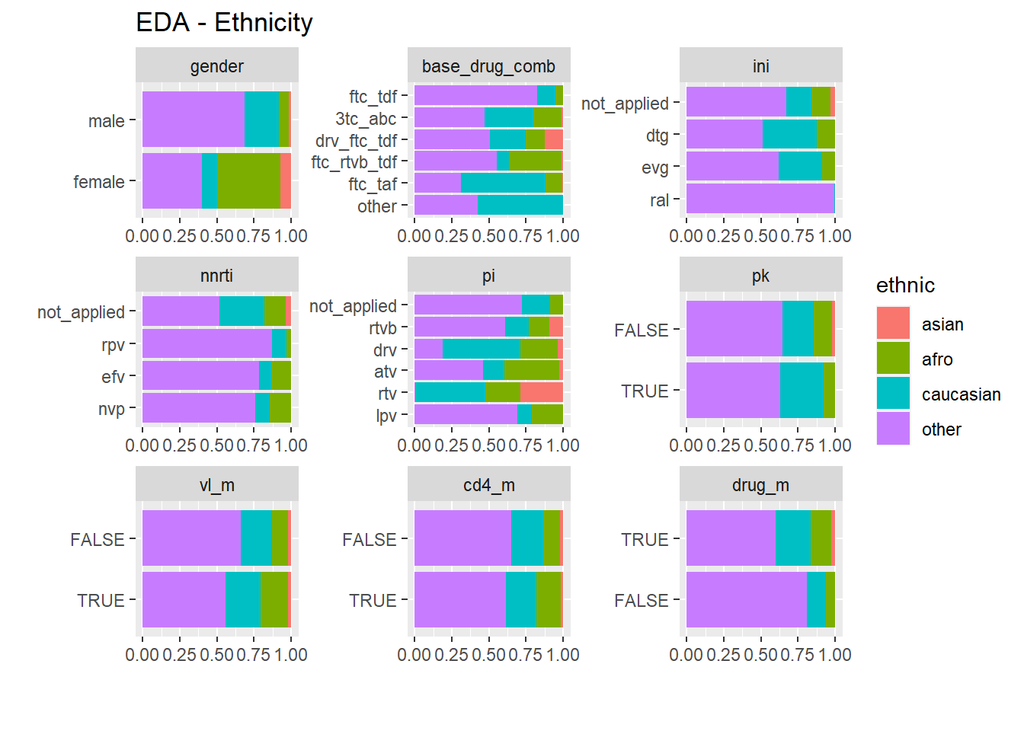

```r
# Plotting distribution of discrete variables
hiv %>% plot_bar(by = 'ethnic', nrow = 4, title = 'EDA - Ethnicity')
```

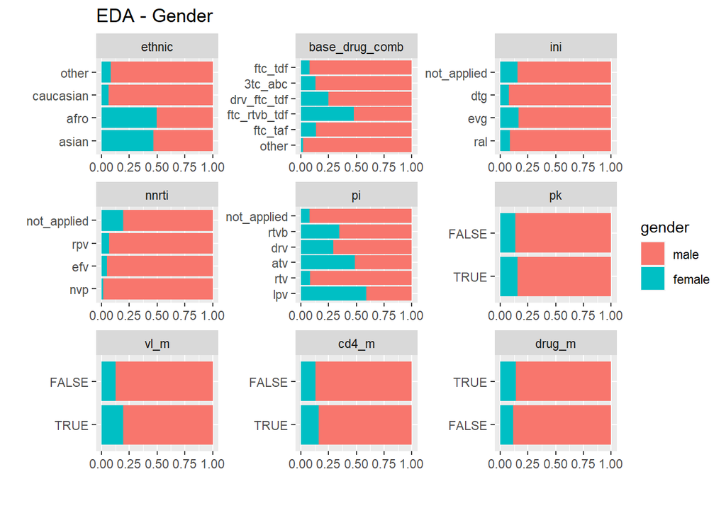

```r
hiv %>% plot_bar(by = 'gender', nrow = 4, title = 'EDA - Gender')
```

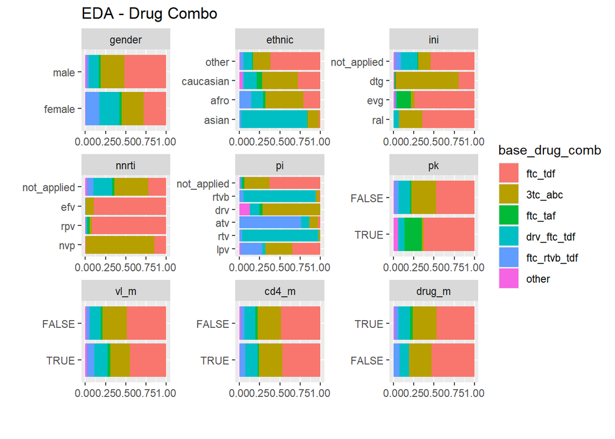

```r
hiv %>% plot_bar(by = 'base_drug_comb', nrow = 4, title = 'EDA - Drug Combo')
```

Let’s move forward to analysis - let’s relevel some variables for later analysis.

```r
# Re-level some variables
hiv$gender <- relevel(hiv$gender, ref = "male")
hiv$ethnic <- relevel(hiv$ethnic, ref = "caucasian")
hiv$base_drug_comb <- relevel(hiv$base_drug_comb, ref = "ftc_tdf")
hiv$ini <- relevel(hiv$ini, ref = "not_applied")
hiv$nnrti <- relevel(hiv$nnrti, ref = "not_applied")
hiv$pi <- relevel(hiv$pi, ref = "not_applied")
```

Let’s separate out each drug into it’s separate binary variables.

Transform the INI, NNRTI, PI variables too.

```r
# Base drug transformation
hiv_trans <- hiv %>%
  mutate(ftc = fifelse(grepl('ftc', base_drug_comb), 1, 0),
         tdf = fifelse(grepl('tdf', base_drug_comb), 1, 0),
         tc3 = fifelse(grepl('3tc', base_drug_comb), 1, 0),
         abc = fifelse(grepl('abc', base_drug_comb), 1, 0),
         taf = fifelse(grepl('taf', base_drug_comb), 1, 0),
         drv_base = fifelse(grepl('drv', base_drug_comb), 1, 0),
         rtvb_base = fifelse(grepl('rtvb', base_drug_comb), 1, 0),
         other_base = fifelse(grepl('other', base_drug_comb), 1, 0))

# INI drug transformation
hiv_trans <- hiv_trans %>%
  mutate(dtg = fifelse(grepl('dtg', ini), 1, 0),
         ral = fifelse(grepl('ral', ini), 1, 0),
         evg = fifelse(grepl('evg', ini), 1, 0),
         ini_not_applied = fifelse(grepl('not_applied', ini), 1, 0))

# NNTRI drug transformation
hiv_trans <- hiv_trans %>%
  mutate(nvp = fifelse(grepl('nvp', nnrti), 1, 0),
         efv = fifelse(grepl('efv', nnrti), 1, 0),
         rpv = fifelse(grepl('rpv', nnrti), 1, 0),
         nnrti_not_applied = fifelse(grepl('not_applied', nnrti), 1, 0))

# PI drug transformation
hiv_trans <- hiv_trans %>%
  mutate(drv_extra_pi = fifelse(grepl('drv', pi), 1, 0),
         rtvb_extra_pi = fifelse(grepl('rtvb', pi), 1, 0),
         lpv = fifelse(grepl('lpv', pi), 1, 0),
         rtv = fifelse(grepl('rtv', pi), 1, 0),
         atv = fifelse(grepl('atv', pi), 1, 0),
         pi_not_applied = fifelse(grepl('not_applied', pi), 1, 0))
```

Let’s extract the NTRI regimen from the base drug combination.

```r
# Extract NRTI regimen
hiv_trans <- hiv_trans %>%
  mutate(nrti_regimen = case_when(base_drug_comb %like% '3tc' ~ '3tc + abc',
                                  base_drug_comb %like% 'taf' ~ 'ftc + taf',
                                  base_drug_comb %like% 'tdf' ~ 'ftc + tdf',
                                  .default = 'other'))
```

Let’s extract the PI regimen - regardless whether it’s administered as part of the base regimen or as extra PI.

```r
# Extract PI regimen
pi_cols <- c("drv_base", "rtvb_base", "drv_extra_pi", "rtvb_extra_pi", "lpv", "atv", "rtv")

hiv_trans <- hiv_trans %>%
  mutate(pi_regimen = apply(hiv_trans[, ..pi_cols], 1, function(row) {

    # Get column names with 1 values
    pi_columns <- names(row[row == 1])

    # Replace "DRV_base" with "DRV" in the column names
    pi_columns <- gsub("drv_base", "drv", pi_columns)

    # Replace "DRV_extra_pi" with "DRV" in the column names
    pi_columns <- gsub("drv_extra_pi", "drv", pi_columns)

    # Replace "RTVB_base" with "RTVB" in the column names
    pi_columns <- gsub("rtvb_base", "rtvb", pi_columns)

    # Replace "RTVB_extra_pi" with "RTVB" in the column names
    pi_columns <- gsub("rtvb_extra_pi", "rtvb", pi_columns)

    # De-duplicate pi_columns (as DRV and RTVB may appear more than once)
    pi_columns <- unique(pi_columns)

    # Concatenate column names with pluses in between
    regimen <- paste(pi_columns, collapse = " + ")

    #Return the PI regimen
    ifelse(regimen == "", "none", regimen)
  }))
```

Let’s extract the INI regimen

```r
# Extract INI regimen
ini_cols <- c("evg", "dtg", "ral")

hiv_trans <- hiv_trans %>%
  mutate(ini_regimen = apply(hiv_trans[, ..ini_cols], 1, function(row) {

    # Get column names with 1 values
    ini_columns <- names(row[row == 1])

    # Concatenate column names with pluses in between
    regimen <- paste(ini_columns, collapse = " + ")

    # Return the INI regimen
    ifelse(regimen == "", "none", regimen)
  }))
```

Let’s extract the NNRTI regimen.

```r
# Extract NNRTI regimen
nnrti_cols <- c("nvp", "efv", "rpv")

hiv_trans <- hiv_trans %>%
  mutate(nnrti_regimen = apply(hiv_trans[, ..nnrti_cols], 1, function(row) {

    #Get column names with 1 values
    nnrti_columns <- names(row[row == 1])

    #Concatenate column names with pluses in between
    regimen <- paste(nnrti_columns, collapse = " + ")

    #Return the NRTI regimen
    ifelse(regimen == "", "none", regimen)
  }))
```

Now, we want to extract all the useful columns that we’ll use for the analysis.

```r
# Extract useful columns
cols_keep = c('id', 'time', 'vl', 'cd4', 'relcd4', 'gender', 'ethnic',
              'nrti_regimen', 'pi_regimen', 'ini_regimen', 'nnrti_regimen', 'pk',
              'vl_m', 'cd4_m', 'drug_m')

hiv_cleaned <- hiv_trans[, ..cols_keep]

# Save the processed data frame
fwrite(hiv_cleaned, file.path('output', "processed_data_hiv.csv"))
```

Factorise the non-factor columns of the cleaned dataset.

```r
# Factorise columns and level based on decreasing frequency
factor_cols <- hiv_cleaned %>% select(nrti_regimen:drug_m) %>% names()
hiv_cleaned[, (factor_cols) := lapply(.SD, factor), .SDcols = factor_cols]
hiv_cleaned[, (factor_cols) := lapply(.SD, fct_infreq), .SDcols = factor_cols]

str(hiv_cleaned)
```

```
## Classes 'data.table' and 'data.frame':   534960 obs. of  15 variables:
##  $ id           : int  0 0 0 0 0 0 0 0 0 0 ...
##  $ time         : int  0 1 2 3 4 5 6 7 8 9 ...
##  $ vl           : num  29.9 29.2 28.7 28.1 28.8 ...
##  $ cd4          : num  793 467 465 692 642 ...
##  $ relcd4       : num  30.8 30.4 30.4 30.2 29.9 ...
##  $ gender       : Factor w/ 2 levels "male","female": 1 1 1 1 1 1 1 1 1 1 ...
##  $ ethnic       : Factor w/ 4 levels "caucasian","asian",..: 1 1 1 1 1 1 1 1 1 1 ...
##  $ nrti_regimen : Factor w/ 4 levels "ftc + tdf","3tc + abc",..: 1 1 1 1 1 1 1 1 1 1 ...
##  $ pi_regimen   : Factor w/ 13 levels "none","drv + rtvb + rtv",..: 1 1 1 1 1 1 1 1 1 1 ...
##  $ ini_regimen  : Factor w/ 4 levels "none","dtg","evg",..: 2 2 2 2 2 2 2 2 2 2 ...
##  $ nnrti_regimen: Factor w/ 4 levels "none","rpv","efv",..: 1 1 1 1 1 1 1 1 1 1 ...
##  $ pk           : Factor w/ 2 levels "FALSE","TRUE": 1 1 1 1 1 1 1 1 1 1 ...
##  $ vl_m         : Factor w/ 2 levels "FALSE","TRUE": 1 1 1 1 1 1 1 1 1 1 ...
##  $ cd4_m        : Factor w/ 2 levels "FALSE","TRUE": 2 1 1 1 1 1 1 2 1 1 ...
##  $ drug_m       : Factor w/ 2 levels "TRUE","FALSE": 1 1 1 1 1 1 1 1 1 1 ...
##  - attr(*, ".internal.selfref")=<externalptr>
```

# Start analysis proper

Let’s first look at how many people changed their regimen?

```r
# How many patients change their regimen at least once?
npatient_regimen_change <- hiv_cleaned[, .N, by = .(id, nrti_regimen, pi_regimen, ini_regimen, nnrti_regimen, pk)][, .(n_regimens = .N), by = id][n_regimens > 1, .N]

# Total number of patients
npatients <- hiv_cleaned[, uniqueN(id)]

c('total unique patients' = npatients, 'patients with regimen changes' = npatient_regimen_change)
```

```
##         total unique patients patients with regimen changes
##                          8916                          5691
```

Out of 8916, 5691 changed regiments, representing 63.8290713% of the cohort

As we are investigating both viral load and immune recovery outcomes, split dataset to 1) people over 1000 VL at time zero and 2) people below 500 CD4 at time zero.

```r
# Get our VL dataset by getting unique patients who started with >1000 VL at time 0
vl_id <- hiv_cleaned[vl > 1000 & time == 0, unique(id)]
vl <- hiv_cleaned[id %in% vl_id]

# Get our CD4 dataset by getting unique patients who started with <500 CD4 at time 0
cd4_id <- hiv_cleaned[cd4 < 500 & time == 0, unique(id)]
cd4 <- hiv_cleaned[id %in% cd4_id]
```

Now we want to restrict the dataset so the dataset only contains rows for each patient up to their censor/first_event timepoint.

```r
# Give outcomes and mark timing for when the event occurred
vl[, `:=`(event = vl <= 1000, event_timing = ifelse(vl <= 1000, time, 59))]
cd4[, `:=`(event = cd4 >= 500, event_timing = ifelse(cd4 >= 500, time, 59))]

# Now for each patient, grab their first event timing
vl_first_event <- vl[, .(first_event = min(event_timing)), by = id]
cd4_first_event <- cd4[, .(first_event = min(event_timing)), by = id]

# Create trimmed dataset
vl_trim <- vl %>%
  left_join(vl_first_event, by = 'id') %>%
  filter(time <= first_event) %>%
  select(-event_timing)

cd4_trim <- cd4 %>%
  left_join(cd4_first_event, by = 'id') %>%
  filter(time <= first_event) %>%
  select(-event_timing)
```

Create an input dataset for modelling involving start-end date for each patient and their treatment regimen. For details, see comments in code below.

```r
# Get distinct episodes for each patient
# `episode_cumu` column only stays the same if there are no patient changes nor treatment regimen changes
vl_episode <- vl_trim %>%
  mutate(episode = fifelse(id == lag(id, default = first(id))
                           & nrti_regimen == lag(nrti_regimen, default = first(nrti_regimen))
                           & pi_regimen == lag(pi_regimen, default = first(pi_regimen))
                           & ini_regimen == lag(ini_regimen, default = first(ini_regimen))
                           & nnrti_regimen == lag(nnrti_regimen, default = first(nnrti_regimen))
                           & pk == lag(pk, default = first(pk)),
                           0, 1),
         episode_cumu = cumsum(episode)
         )

# Getting start and stop times for each independent episode
splits <- vl_episode[, .(start = min(time), time = max(time)), by = .(id, episode_cumu)]

# Inner join so that everyone only has rows indicating the start and end timepoint of each distinct episode
vl_final <- vl_episode %>%
  inner_join(splits, by = c('id', 'time', 'episode_cumu')) %>%
  mutate(stop = time) %>%
  select(-episode, -episode_cumu)

# Since current censoring timepoint is the timepoint immediate prior to change,
# we want to increment current stop timepoint by 1 to indicate the actual censoring timepoint
vl_final[, stop := stop + 1]

# Of course, we don't want to increment the ultimate censoring timepoint at which
# people reached the event or past timepoint 59.
# Thus we limit max stop point to the timepoint of ultimate patient censoring
vl_final[, stop := fifelse(stop > first_event, first_event, stop)]

# Re-create event flag to align against new stop date
# See patient ID 2 as example
# Patient 2 reached <1000 VL at time 37
# However at the same timepoint they also changed PI regimens
# Now, does their regimen change count as a line?
# It shouldn't since we're assuming that he reached <1000 VL at timepoint 37
# before he changed medication
# Thus we'd keep his first regimen but discard his second
# This is the purpose of the code below for creating new flag then dedupe
vl_final <- vl_final[, event := fifelse(stop == first_event, TRUE, FALSE)] %>%
  distinct(id, event, .keep_all = TRUE)
```

Repeat the same process for CD4 model.

```r
# For more details see code above
cd4_episode <- cd4_trim %>%
  mutate(episode = fifelse(id == lag(id, default = first(id))
                           & nrti_regimen == lag(nrti_regimen, default = first(nrti_regimen))
                           & pi_regimen == lag(pi_regimen, default = first(pi_regimen))
                           & ini_regimen == lag(ini_regimen, default = first(ini_regimen))
                           & nnrti_regimen == lag(nnrti_regimen, default = first(nnrti_regimen))
                           & pk == lag(pk, default = first(pk)),
                           0, 1),
         episode_cumu = cumsum(episode)
         )


splits <- cd4_episode[, .(start = min(time), time = max(time)), by = .(id, episode_cumu)]


cd4_final <- cd4_episode %>%
  inner_join(splits, by = c('id', 'time', 'episode_cumu')) %>%
  mutate(stop = time) %>%
  select(-episode, -episode_cumu)

cd4_final[, stop := stop + 1]

cd4_final[, stop := fifelse(stop > first_event, first_event, stop)]

cd4_final <- cd4_final[, event := fifelse(stop == first_event, TRUE, FALSE)] %>%
  distinct(id, event, .keep_all = TRUE)
```

# Build Cox model!!!!!!!

Let’s build time-varying Cox model starting with Viral load model.

```r
# Build time-varying Cox model for VL
vl_mod <- coxph(Surv(start, stop, event) ~ relcd4 + gender + ethnic + nrti_regimen + pi_regimen + ini_regimen + nnrti_regimen + pk + cluster(id), data = vl_final)

# Display results
results <- tidy(vl_mod, conf.int = TRUE, exp = T)
results %>% fwrite(file.path('output', 'vl_results.csv'))
summary(vl_mod)
```

```
## Call:
## coxph(formula = Surv(start, stop, event) ~ relcd4 + gender +
##     ethnic + nrti_regimen + pi_regimen + ini_regimen + nnrti_regimen +
##     pk, data = vl_final, cluster = id)
##
##   n= 7620, number of events= 5612
##
##                                  coef  exp(coef)   se(coef)  robust se       z
## relcd4                     -0.0110282  0.9890324  0.0007782  0.0009019 -12.228
## genderfemale               -0.3657362  0.6936858  0.0481698  0.0494311  -7.399
## ethnicasian                        NA         NA  0.0000000  0.0000000      NA
## ethnicafro                 -0.2095195  0.8109738  0.0644134  0.0731533  -2.864
## ethnicother                -0.1823899  0.8332764  0.0383731  0.0533101  -3.421
## nrti_regimen3tc + abc       0.0259530  1.0262927  0.0560580  0.0739563   0.351
## nrti_regimenftc + taf      -1.6094455  0.1999985  1.0104805  0.1863566  -8.636
## nrti_regimenother           1.3802433  3.9758687  0.5809492  0.7114529   1.940
## pi_regimendrv + rtvb + rtv -0.1049710  0.9003507  0.0840458  0.1162853  -0.903
## pi_regimendrv               0.7023810  2.0185531  0.0767125  0.1161284   6.048
## pi_regimenrtvb + atv        0.4455141  1.5612926  0.0911186  0.1172093   3.801
## pi_regimendrv + rtv        -1.4257692  0.2403235  0.1539320  0.1516462  -9.402
## pi_regimenrtvb + rtv        0.7115639  2.0371748  0.1424296  0.2879288   2.471
## pi_regimenatv               0.0388032  1.0395659  0.3852908  0.3127791   0.124
## pi_regimenrtvb              1.0814789  2.9490377  0.1063965  0.1302819   8.301
## pi_regimendrv + atv        -0.1038449  0.9013651  0.2254569  0.3486494  -0.298
## pi_regimenlpv               2.3170510 10.1457102  0.3855227  0.2221408  10.431
## pi_regimenrtv                      NA         NA  0.0000000  0.0000000      NA
## pi_regimenrtvb + lpv        1.9366630  6.9355686  0.5831523  0.4478489   4.324
## pi_regimendrv + lpv                NA         NA  0.0000000  0.0000000      NA
## ini_regimendtg             -1.0702260  0.3429310  0.0784518  0.1071575  -9.987
## ini_regimenevg             -0.2787908  0.7566982  0.1117373  0.1409810  -1.978
## ini_regimenral             -0.8059594  0.4466592  0.0758281  0.0951570  -8.470
## nnrti_regimenrpv           -0.1764029  0.8382802  0.0741950  0.1025486  -1.720
## nnrti_regimenefv            0.1545334  1.1671132  0.0797417  0.1053359   1.467
## nnrti_regimennvp            0.1433580  1.1541430  0.1054996  0.1107814   1.294
## pkTRUE                     -0.5443110  0.5802414  0.1068464  0.1233805  -4.412
##                            Pr(>|z|)
## relcd4                      < 2e-16 ***
## genderfemale               1.37e-13 ***
## ethnicasian                      NA
## ethnicafro                 0.004182 **
```

[output cut: 47 more lines]

```
## ini_regimendtg                0.3429    2.91604    0.2780    0.4231
## ini_regimenevg                0.7567    1.32153    0.5740    0.9975
## ini_regimenral                0.4467    2.23884    0.3707    0.5382
## nnrti_regimenrpv              0.8383    1.19292    0.6856    1.0249
## nnrti_regimenefv              1.1671    0.85681    0.9494    1.4347
## nnrti_regimennvp              1.1541    0.86644    0.9289    1.4340
## pkTRUE                        0.5802    1.72342    0.4556    0.7390
##
## Concordance= 0.676  (se = 0.005 )
## Likelihood ratio test= 1703  on 24 df,   p=<2e-16
## Wald test            = 1327  on 24 df,   p=<2e-16
## Score (logrank) test = 1936  on 24 df,   p=<2e-16,   Robust = 1359  p=<2e-16
##
##   (Note: the likelihood ratio and score tests assume independence of
##      observations within a cluster, the Wald and robust score tests do not).
```

```
## Model matrix is rank deficient. Parameters `ethnicasian, pi_regimenrtv,
##   pi_regimendrv + lpv` were not estimable.
```

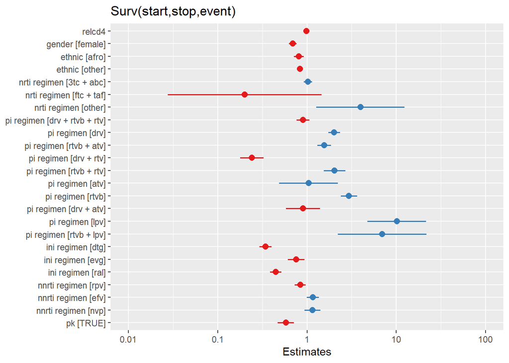

```r
sjPlot::plot_model(vl_mod)
```

```r
ggsave(file.path('output', 'vl_results_image.png'))
results
```

```
## # A tibble: 27 × 8
##    term      estimate std.error robust.se statistic   p.value conf.low conf.high
##    <chr>        <dbl>     <dbl>     <dbl>     <dbl>     <dbl>    <dbl>     <dbl>
##  1 relcd4       0.989  0.000778  0.000902   -12.2    2.21e-34    0.987     0.991
##  2 genderfe…    0.694  0.0482    0.0494      -7.40   1.37e-13    0.630     0.764
##  3 ethnicas…   NA      0         0           NA     NA          NA        NA
##  4 ethnicaf…    0.811  0.0644    0.0732      -2.86   4.18e- 3    0.703     0.936
##  5 ethnicot…    0.833  0.0384    0.0533      -3.42   6.23e- 4    0.751     0.925
##  6 nrti_reg…    1.03   0.0561    0.0740       0.351  7.26e- 1    0.888     1.19
##  7 nrti_reg…    0.200  1.01      0.186       -8.64   5.80e-18    0.139     0.288
##  8 nrti_reg…    3.98   0.581     0.711        1.94   5.24e- 2    0.986    16.0
##  9 pi_regim…    0.900  0.0840    0.116       -0.903  3.67e- 1    0.717     1.13
## 10 pi_regim…    2.02   0.0767    0.116        6.05   1.46e- 9    1.61      2.53
## # ℹ 17 more rows
```

```r
vl_mod
```

```
## Call:
## coxph(formula = Surv(start, stop, event) ~ relcd4 + gender +
##     ethnic + nrti_regimen + pi_regimen + ini_regimen + nnrti_regimen +
##     pk, data = vl_final, cluster = id)
##
##                                  coef  exp(coef)   se(coef)  robust se       z
## relcd4                     -0.0110282  0.9890324  0.0007782  0.0009019 -12.228
## genderfemale               -0.3657362  0.6936858  0.0481698  0.0494311  -7.399
## ethnicasian                        NA         NA  0.0000000  0.0000000      NA
## ethnicafro                 -0.2095195  0.8109738  0.0644134  0.0731533  -2.864
## ethnicother                -0.1823899  0.8332764  0.0383731  0.0533101  -3.421
## nrti_regimen3tc + abc       0.0259530  1.0262927  0.0560580  0.0739563   0.351
## nrti_regimenftc + taf      -1.6094455  0.1999985  1.0104805  0.1863566  -8.636
## nrti_regimenother           1.3802433  3.9758687  0.5809492  0.7114529   1.940
## pi_regimendrv + rtvb + rtv -0.1049710  0.9003507  0.0840458  0.1162853  -0.903
## pi_regimendrv               0.7023810  2.0185531  0.0767125  0.1161284   6.048
## pi_regimenrtvb + atv        0.4455141  1.5612926  0.0911186  0.1172093   3.801
## pi_regimendrv + rtv        -1.4257692  0.2403235  0.1539320  0.1516462  -9.402
## pi_regimenrtvb + rtv        0.7115639  2.0371748  0.1424296  0.2879288   2.471
## pi_regimenatv               0.0388032  1.0395659  0.3852908  0.3127791   0.124
## pi_regimenrtvb              1.0814789  2.9490377  0.1063965  0.1302819   8.301
## pi_regimendrv + atv        -0.1038449  0.9013651  0.2254569  0.3486494  -0.298
## pi_regimenlpv               2.3170510 10.1457102  0.3855227  0.2221408  10.431
## pi_regimenrtv                      NA         NA  0.0000000  0.0000000      NA
## pi_regimenrtvb + lpv        1.9366630  6.9355686  0.5831523  0.4478489   4.324
## pi_regimendrv + lpv                NA         NA  0.0000000  0.0000000      NA
## ini_regimendtg             -1.0702260  0.3429310  0.0784518  0.1071575  -9.987
## ini_regimenevg             -0.2787908  0.7566982  0.1117373  0.1409810  -1.978
## ini_regimenral             -0.8059594  0.4466592  0.0758281  0.0951570  -8.470
## nnrti_regimenrpv           -0.1764029  0.8382802  0.0741950  0.1025486  -1.720
## nnrti_regimenefv            0.1545334  1.1671132  0.0797417  0.1053359   1.467
## nnrti_regimennvp            0.1433580  1.1541430  0.1054996  0.1107814   1.294
## pkTRUE                     -0.5443110  0.5802414  0.1068464  0.1233805  -4.412
##                                   p
## relcd4                      < 2e-16
## genderfemale               1.37e-13
## ethnicasian                      NA
## ethnicafro                 0.004182
## ethnicother                0.000623
## nrti_regimen3tc + abc      0.725646
```

[output cut: 9 more lines]

```
## pi_regimendrv + atv        0.765818
## pi_regimenlpv               < 2e-16
## pi_regimenrtv                    NA
## pi_regimenrtvb + lpv       1.53e-05
## pi_regimendrv + lpv              NA
## ini_regimendtg              < 2e-16
## ini_regimenevg             0.047984
## ini_regimenral              < 2e-16
## nnrti_regimenrpv           0.085398
## nnrti_regimenefv           0.142362
## nnrti_regimennvp           0.195644
## pkTRUE                     1.03e-05
##
## Likelihood ratio test=1703  on 24 df, p=< 2.2e-16
## n= 7620, number of events= 5612
```

It’s seems like the cox proportional hazards assumption does not hold for the VL-model:

```r
ggcoxzph((cox.zph(vl_mod)))[1]
```

```
## $`1`
```

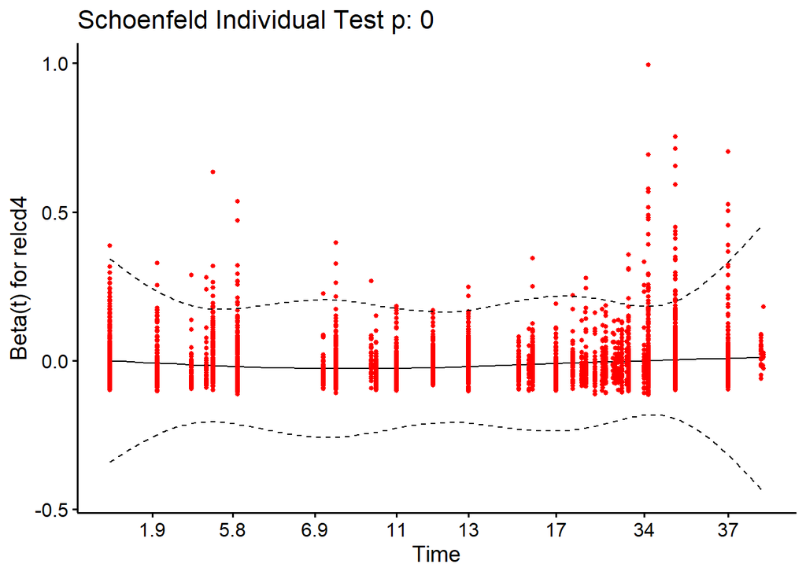

```r
ggcoxzph((cox.zph(vl_mod)))[2]
```

```
## $`2`
```

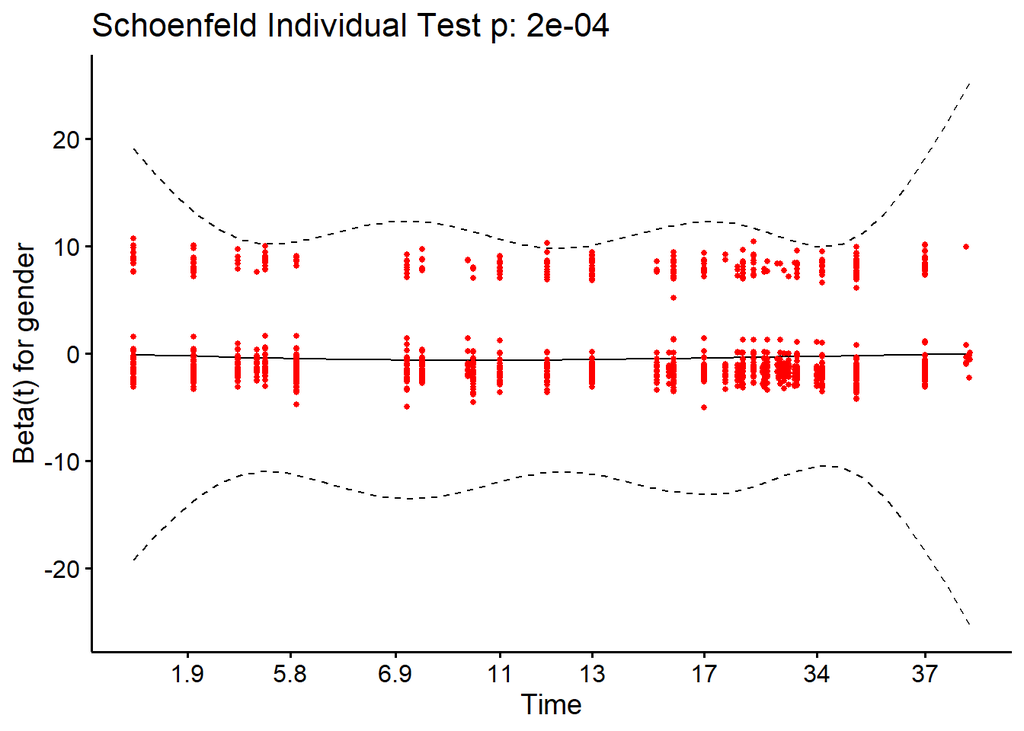

```r
ggcoxzph((cox.zph(vl_mod)))[3]
```

```
## $`3`
```

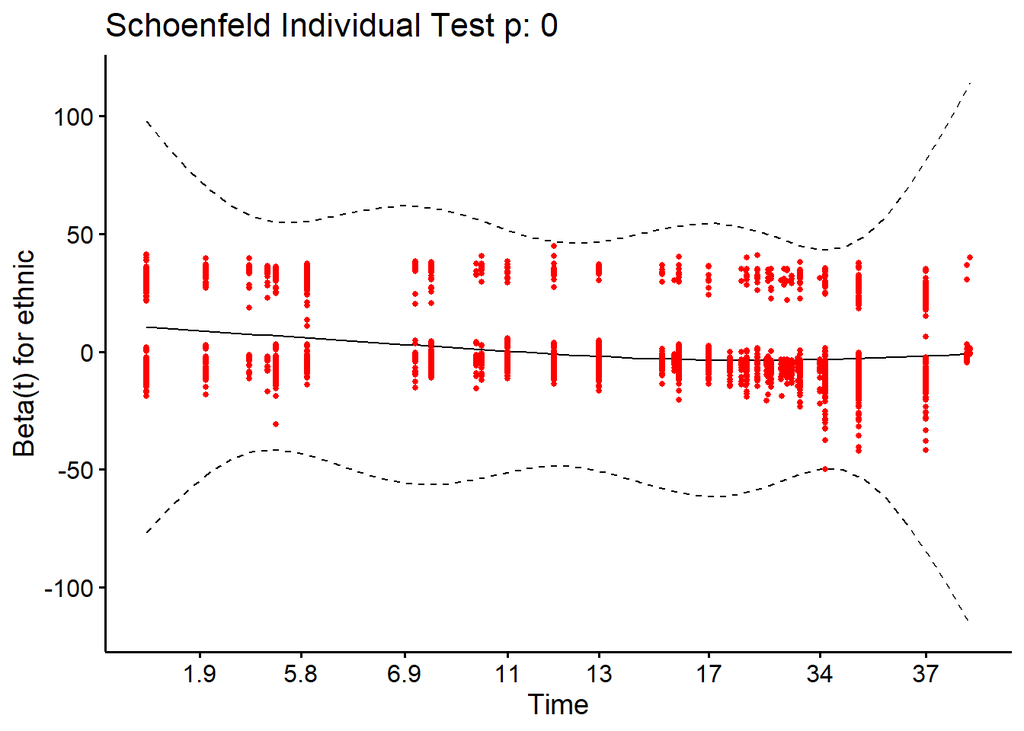

```r
ggcoxzph((cox.zph(vl_mod)))[4]
```

```
## $`4`
```

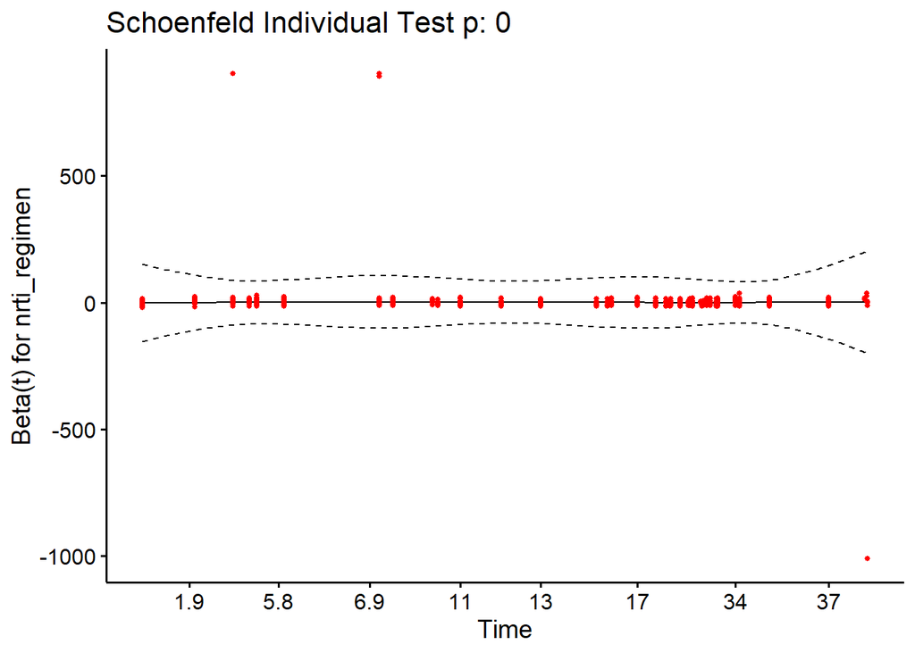

```r
ggcoxzph((cox.zph(vl_mod)))[5]
```

```
## $`5`
```

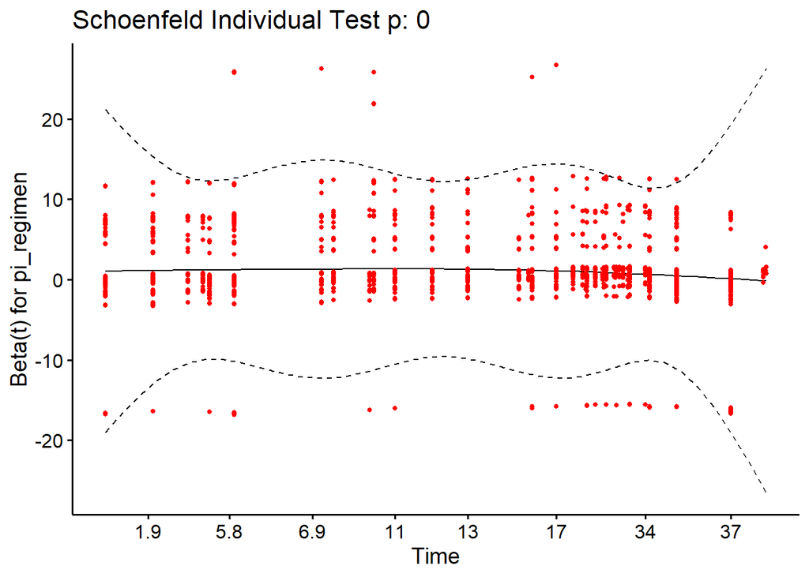

```r
ggcoxzph((cox.zph(vl_mod)))[6]
```

```
## $`6`
```

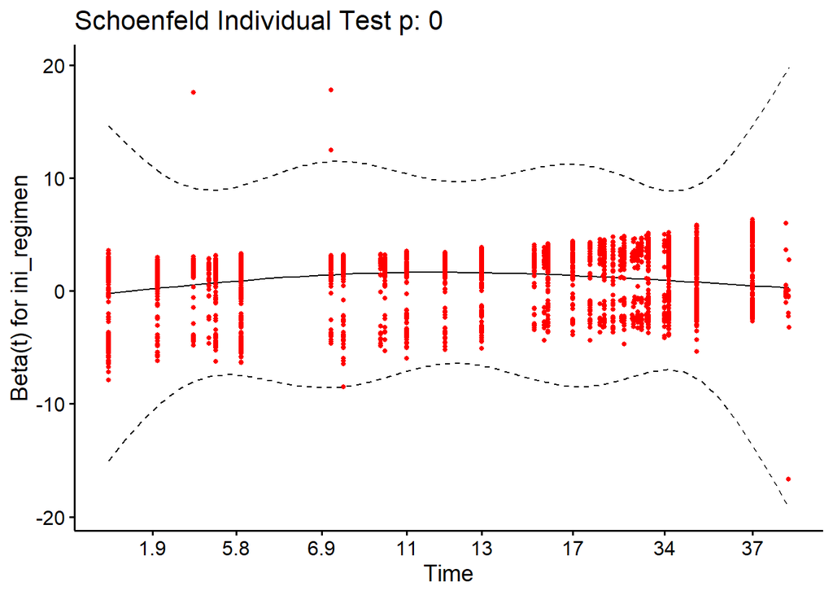

```r
ggcoxzph((cox.zph(vl_mod)))[7]
```

```
## $`7`
```

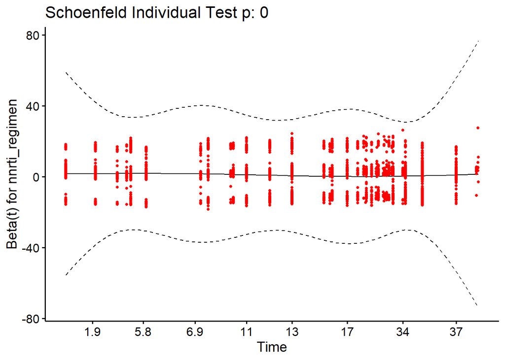

```r
ggcoxzph((cox.zph(vl_mod)))[8]
```

```
## $`8`
```

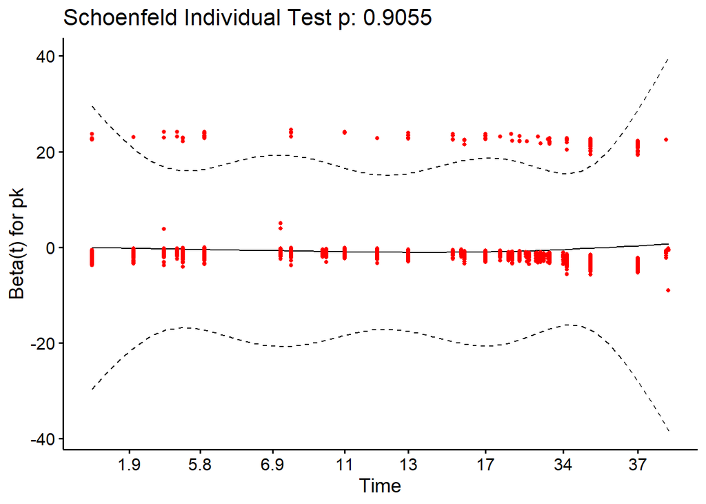

Let’s build time-varying Cox model starting with CD4 model.

```r
# Build time-varying Cox model for CD4
cd4_mod <- coxph(Surv(start, stop, event) ~ vl + gender + ethnic + nrti_regimen + pi_regimen + ini_regimen + nnrti_regimen + pk + cluster(id), data = cd4_final)

# Display results
results <- tidy(cd4_mod, conf.int = TRUE, exp = T)
results %>% fwrite(file.path('output', 'cd4_results.csv'))
summary(cd4_mod)
```

```
## Call:
## coxph(formula = Surv(start, stop, event) ~ vl + gender + ethnic +
##     nrti_regimen + pi_regimen + ini_regimen + nnrti_regimen +
##     pk, data = cd4_final, cluster = id)
##
##   n= 5570, number of events= 3932
##
##                                  coef  exp(coef)   se(coef)  robust se      z
## vl                          1.517e-05  1.000e+00  1.389e-06  1.837e-06  8.255
## genderfemale                2.072e-02  1.021e+00  6.064e-02  5.662e-02  0.366
## ethnicasian                 3.190e-02  1.032e+00  1.882e-01  2.335e-01  0.137
## ethnicafro                 -5.579e-01  5.724e-01  8.588e-02  8.999e-02 -6.200
## ethnicother                 8.360e-02  1.087e+00  6.532e-02  8.062e-02  1.037
## nrti_regimen3tc + abc      -3.195e-01  7.265e-01  6.474e-02  6.584e-02 -4.852
## nrti_regimenftc + taf      -9.077e-02  9.132e-01  1.223e-01  9.337e-02 -0.972
## nrti_regimenother           6.387e-02  1.066e+00  1.613e-01  1.533e-01  0.417
## pi_regimendrv + rtvb + rtv -7.066e-01  4.933e-01  1.003e-01  9.454e-02 -7.474
## pi_regimendrv               1.142e-01  1.121e+00  1.105e-01  1.045e-01  1.092
## pi_regimenrtvb + atv       -6.799e-03  9.932e-01  1.178e-01  1.222e-01 -0.056
## pi_regimendrv + rtv        -1.452e-01  8.648e-01  1.600e-01  1.810e-01 -0.802
## pi_regimenrtvb + rtv        6.256e-01  1.869e+00  1.669e-01  2.196e-01  2.849
## pi_regimenatv               1.261e+00  3.527e+00  3.164e-01  5.329e-01  2.366
## pi_regimenrtvb              1.458e+00  4.296e+00  1.786e-01  1.918e-01  7.601
## pi_regimendrv + atv        -2.076e-01  8.125e-01  2.159e-01  2.439e-01 -0.851
## pi_regimenlpv               1.147e+00  3.147e+00  3.044e-01  6.537e-01  1.754
## pi_regimenrtv               2.273e+00  9.708e+00  7.192e-01  6.996e-01  3.249
## pi_regimenrtvb + lpv       -1.190e-01  8.878e-01  7.143e-01  6.839e-01 -0.174
## pi_regimendrv + lpv                NA         NA  0.000e+00  0.000e+00     NA
## ini_regimendtg              1.287e-01  1.137e+00  1.127e-01  1.081e-01  1.190
## ini_regimenevg              5.700e-02  1.059e+00  1.440e-01  1.335e-01  0.427
## ini_regimenral             -1.855e-01  8.307e-01  1.160e-01  9.659e-02 -1.920
## nnrti_regimenrpv            9.130e-02  1.096e+00  8.984e-02  8.937e-02  1.022
## nnrti_regimenefv            2.460e-01  1.279e+00  9.206e-02  9.282e-02  2.650
## nnrti_regimennvp            2.792e-01  1.322e+00  1.166e-01  1.127e-01  2.479
## pkTRUE                     -2.684e-01  7.646e-01  1.172e-01  1.039e-01 -2.582
##                            Pr(>|z|)
## vl                          < 2e-16 ***
## genderfemale                0.71437
## ethnicasian                 0.89132
## ethnicafro                 5.64e-10 ***
```

[output cut: 47 more lines]

```
## ini_regimendtg                1.1373     0.8793    0.9201    1.4058
## ini_regimenevg                1.0587     0.9446    0.8150    1.3752
## ini_regimenral                0.8307     1.2038    0.6874    1.0039
## nnrti_regimenrpv              1.0956     0.9127    0.9196    1.3053
## nnrti_regimenefv              1.2788     0.7820    1.0661    1.5340
## nnrti_regimennvp              1.3221     0.7564    1.0602    1.6487
## pkTRUE                        0.7646     1.3078    0.6237    0.9374
##
## Concordance= 0.67  (se = 0.006 )
## Likelihood ratio test= 658.4  on 26 df,   p=<2e-16
## Wald test            = 735.3  on 26 df,   p=<2e-16
## Score (logrank) test = 754  on 26 df,   p=<2e-16,   Robust = 554.1  p=<2e-16
##
##   (Note: the likelihood ratio and score tests assume independence of
##      observations within a cluster, the Wald and robust score tests do not).
```

```
## Model matrix is rank deficient. Parameters `pi_regimendrv + lpv` were
##   not estimable.
```

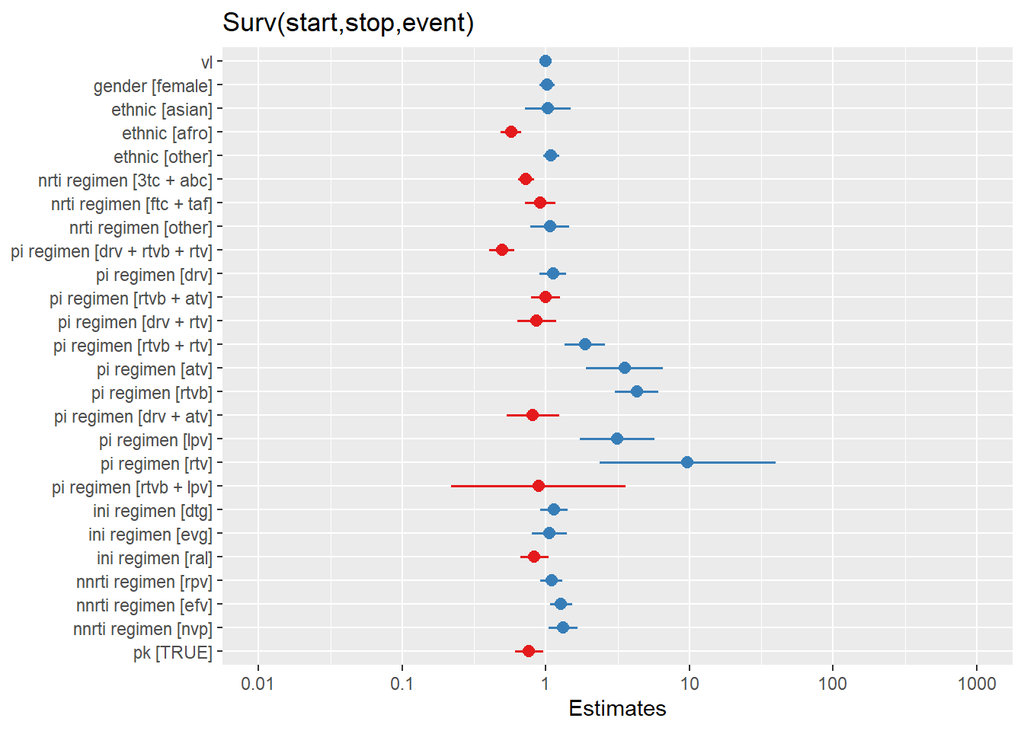

```r
sjPlot::plot_model(cd4_mod)
```

```r
ggsave(file.path('output', 'cd4_results_image.png'))
results
```

```
## # A tibble: 27 × 8
##    term       estimate std.error robust.se statistic  p.value conf.low conf.high
##    <chr>         <dbl>     <dbl>     <dbl>     <dbl>    <dbl>    <dbl>     <dbl>
##  1 vl            1.00    1.39e-6   1.84e-6     8.25  1.52e-16    1.00      1.00
##  2 genderfem…    1.02    6.06e-2   5.66e-2     0.366 7.14e- 1    0.914     1.14
##  3 ethnicasi…    1.03    1.88e-1   2.33e-1     0.137 8.91e- 1    0.653     1.63
##  4 ethnicafro    0.572   8.59e-2   9.00e-2    -6.20  5.64e-10    0.480     0.683
##  5 ethnicoth…    1.09    6.53e-2   8.06e-2     1.04  3.00e- 1    0.928     1.27
##  6 nrti_regi…    0.727   6.47e-2   6.58e-2    -4.85  1.22e- 6    0.639     0.827
##  7 nrti_regi…    0.913   1.22e-1   9.34e-2    -0.972 3.31e- 1    0.760     1.10
##  8 nrti_regi…    1.07    1.61e-1   1.53e-1     0.417 6.77e- 1    0.789     1.44
##  9 pi_regime…    0.493   1.00e-1   9.45e-2    -7.47  7.80e-14    0.410     0.594
## 10 pi_regime…    1.12    1.10e-1   1.05e-1     1.09  2.75e- 1    0.913     1.38
## # ℹ 17 more rows
```

It’s seems like the cox proportional hazards assumption does not hold also for the CD4-model:

```r
ggcoxzph((cox.zph(cd4_mod)))[1]
```

```
## $`1`
```

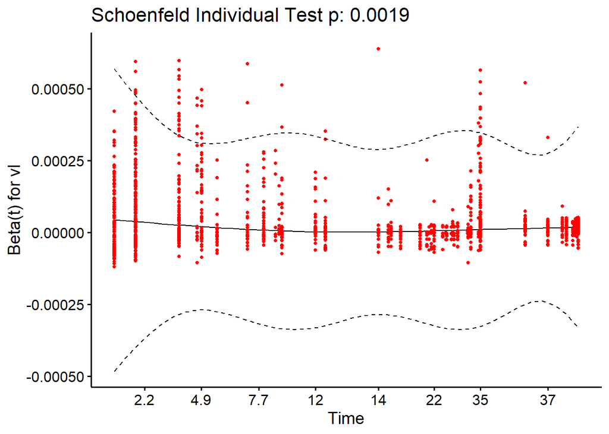

```r
ggcoxzph((cox.zph(cd4_mod)))[2]
```

```
## $`2`
```

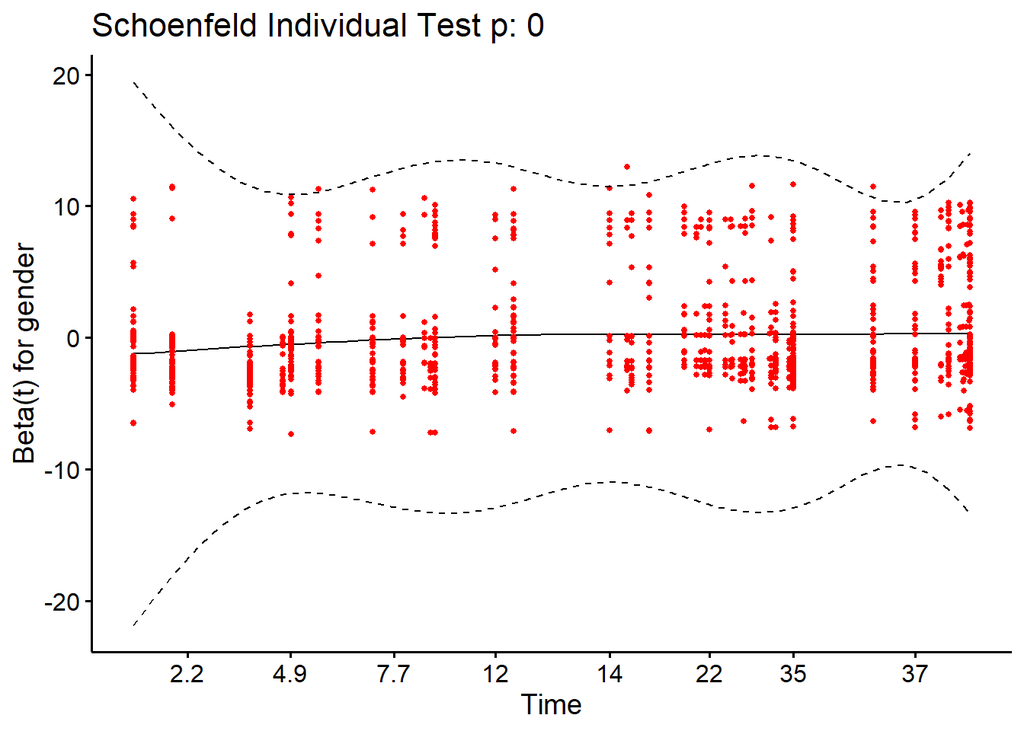

```r
ggcoxzph((cox.zph(cd4_mod)))[3]
```

```
## $`3`
```

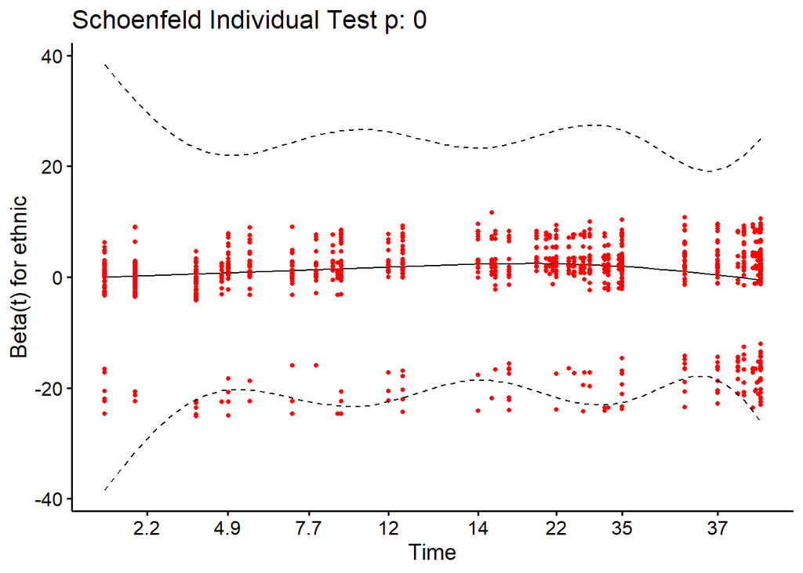

```r
ggcoxzph((cox.zph(cd4_mod)))[4]
```

```
## $`4`
```

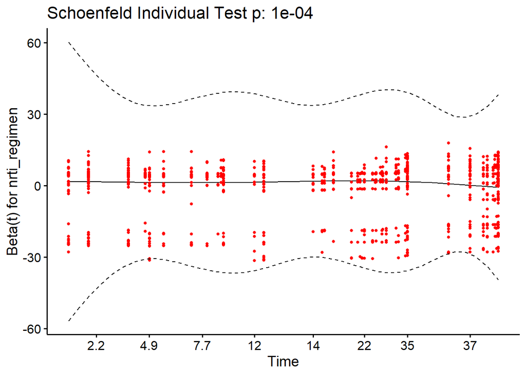

```r
ggcoxzph((cox.zph(cd4_mod)))[5]
```

```
## $`5`
```

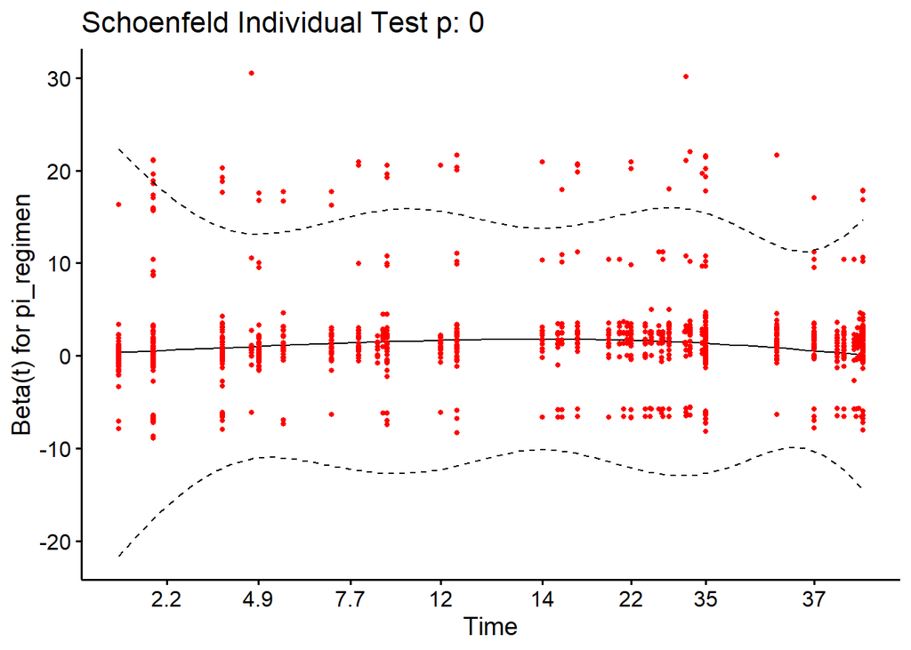

```r
ggcoxzph((cox.zph(cd4_mod)))[6]
```

```
## $`6`
```

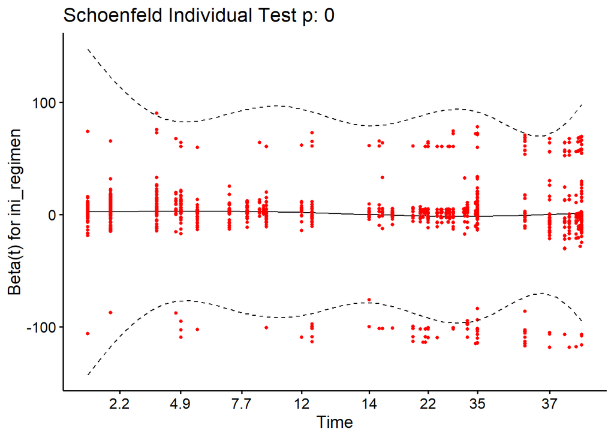

```r
ggcoxzph((cox.zph(cd4_mod)))[7]
```

```
## $`7`
```

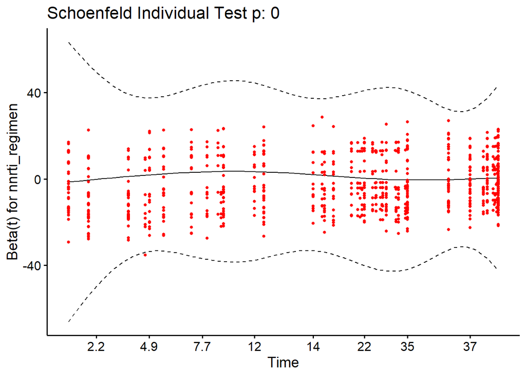

```r
ggcoxzph((cox.zph(cd4_mod)))[8]
```

```
## $`8`
```

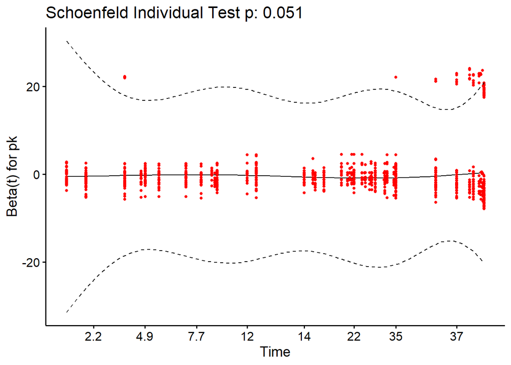

- The only variable for which the cox proportional hazard assumption seems to hold is the pk-enhancer variable in both models (although the Schoenfeld test is barely non-significant in the CD4-model).